# hw06

### Exercises 14.3.2.1

1. How would you match the literal string “$^$”?

```r
# You could match it using the following
d <- c("purple$^$rain", "$^$purplerain", "purplerain$^$")
writeLines(d)
```

```
## purple$^$rain
## $^$purplerain
## purplerain$^$
```

```r
str_view(d, "\\$\\^\\$") #all
```

[interactive chart not shown]

```r
str_view(d, "^\\$\\^\\$") # at beginning
```

[interactive chart not shown]

```r
str_view(d, "\\$\\^\\$$") #at the end
```

[interactive chart not shown]

2. Given the corpus of common words in stringr::words, create regular expressions that find all words that:

Start with “y”. End with “x” Are exactly three letters long. (Don’t cheat by using str_length()!) Have seven letters or more. Since this list is long, you might want to use the match argument to str_view() to show only the matching or non-matching words.

```r
str_view(words, "^y", match = TRUE) # starts with y
```

[interactive chart not shown]

```r
str_view(words, "x$", match=TRUE) # ends with x
```

[interactive chart not shown]

```r
str_view(words, "^...$", match=TRUE) #three letters - specify beginning and end with three letters in between
```

[interactive chart not shown]

```r
str_view(words, ".......", match=TRUE) # seven or more letters -specify at least seven letters
```

[interactive chart not shown]

### Exercises 14.3.3.1

Create regular expressions to find all words that:

Start with a vowel.

That only contain consonants. (Hint: thinking about matching “not”-vowels.)

End with ed, but not with eed.

End with ing or ise.

Empirically verify the rule “i before e except after c”.

Is “q” always followed by a “u”?

Write a regular expression that matches a word if it’s probably written in British English, not American English.

Create a regular expression that will match telephone numbers as commonly written in your country.

```r
#start with a vowel
str_view(words, "^[aeiouy]", match=TRUE)
```

[interactive chart not shown]

```r
#contain only consonants
str_view(words, "^[^aeiouy]*$", match=TRUE)
```

[interactive chart not shown]

```r
#end with ed
str_view(words, "[^e]ed$", match=TRUE)
```

[interactive chart not shown]

```r
#end with ing or ise
str_view(words, "$ing|ise", match=TRUE)
```

[interactive chart not shown]

```r
#i before e except after c always true?
#no, weight is counter to the rule
str_view(words, "[^c]ei", match=TRUE)
```

[interactive chart not shown]

```r
#q always followed by u?
#Yes it is!
str_view(words, "q[^u]", match=TRUE)
```

[interactive chart not shown]

```r
#regular expression for a British English word
str_view(words, "..our$", match=TRUE)
```

[interactive chart not shown]

```r
#regular expression that will match telephone numbers as commonly written in your country
e <-("780-555-3232, 91-783-45648, 604-555-7777")
str_view_all(e, "\\d{3}-\\d{3}-\\d{4}", match=TRUE)
```

[interactive chart not shown]

### Exercises 14.3.4.1

Describe the equivalents of ?, +, * in {m,n} form.

```r
f <- "1888 is the longest year in Roman numerals: MDCCCLXXXVIII"
# ? = {1}
# In this case C? is equivalent to C{1}
str_view(f, "C?")
```

[interactive chart not shown]

```r
str_view(f, "C{1}")
```

[interactive chart not shown]

```r
# + = {1,}
#In this case C+ is equivalent to C{1,}
str_view(f, "C+")
```

[interactive chart not shown]

```r
str_view(f, "C{1,}")
```

[interactive chart not shown]

```r
# * = {0,}
#In this case * is equivalent to C{0,}
str_view(f, "C*")
```

[interactive chart not shown]

```r
str_view(f, "C{0,}")
```

[interactive chart not shown]

Describe in words what these regular expressions match: (read carefully to see if I’m using a regular expression or a string that defines a regular expression.)

```r
# ^.*$  will match anything, even if it is length zero
# "\\{.+\\}" will match {(at least one character)}
# \d{4}-\d{2}-\d{2} will match 4 digits-2 digits-2 digits
# "\\\\{4}" will match \\\\
```

Create regular expressions to find all words that:

Start with three consonants. Have three or more vowels in a row. Have two or more vowel-consonant pairs in a row. Solve the beginner regexp crosswords at https://regexcrossword.com/challenges/beginner.

```r
#begins with three consonants
str_view(words, "^[^aeiouy]{3}", match=TRUE)
```

[interactive chart not shown]

```r
#three or more vowels in a row
str_view(words, "[aeiouy]{3,}", match=TRUE)
```

[interactive chart not shown]

```r
#have two or more vowel-constant pairs in a row
str_view(words, "([aeiouy][^aeiouy]){2,}", match=TRUE)
```

[interactive chart not shown]

Solved beginner regexp crossword

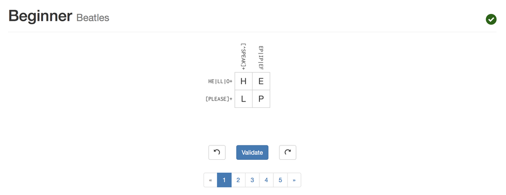

### Exercises 14.3.5.1

Describe, in words, what these expressions will match:

```r
g <- "aaabcbbabbaabab"
str_view(g, "(.)\\1\\1")
```

[interactive chart not shown]

```r
str_view(g, "(.)(.)\\2\\1")
```

[interactive chart not shown]

```r
str_view(g, "(..)\\1")
```

[interactive chart not shown]

```r
h <- "bcbdb"
str_view(h, "(.).\\1.\\1")
```

[interactive chart not shown]

```r
i <- "abcdecba"
str_view(i, "(.)(.)(.).*\\3\\2\\1")
```

[interactive chart not shown]

Construct regular expressions to match words that:

Start and end with the same character.

Contain a repeated pair of letters (e.g. “church” contains “ch” repeated twice.)

Contain one letter repeated in at least three places (e.g. “eleven” contains three “e”s.)

```r
#words begin and end with the same letter
str_view(words, "^(.).*\\1$", match=TRUE)
```

[interactive chart not shown]

```r
#Contain a repeated pair of letters
str_view(words, "(..).*\\1", match=TRUE)
```

[interactive chart not shown]

```r
#Contain one letter repeated in at least three places
str_view(words, "(.).*\\1.*\\1", match=TRUE)
```

[interactive chart not shown]

### Exercises 14.4.2

For each of the following challenges, try solving it by using both a single regular expression, and a combination of multiple str_detect() calls.

Find all words that start or end with x.

Find all words that start with a vowel and end with a consonant.

Are there any words that contain at least one of each different vowel?

What word has the highest number of vowels? What word has the highest proportion of vowels? (Hint: what is the denominator?)

```r
# Find all words that start or end with x
str_view(words, "^x|x$", match=TRUE)
```

[interactive chart not shown]

```r
words[str_detect(words, "^x") | str_detect(words, "x$")]
```

```
## [1] "box" "sex" "six" "tax"
```

```r
#Find all words that start with a vowel and end with a consonant
str_view(words, "^[aeiouy].*[^aeiouy]$", match=TRUE)
```

[interactive chart not shown]

```r
words[str_detect(words, "^[aeiouy]") & str_detect(words, "[^aeiouy]$")]
```

```
##   [1] "about"       "accept"      "account"     "across"      "act"
##   [6] "actual"      "add"         "address"     "admit"       "affect"
##  [11] "afford"      "after"       "afternoon"   "again"       "against"
##  [16] "agent"       "air"         "all"         "allow"       "almost"
##  [21] "along"       "alright"     "although"    "always"      "amount"
##  [26] "and"         "another"     "answer"      "apart"       "apparent"
##  [31] "appear"      "appoint"     "approach"    "arm"         "around"
##  [36] "art"         "as"          "ask"         "at"          "attend"
##  [41] "awful"       "each"        "east"        "eat"         "effect"
##  [46] "egg"         "eight"       "either"      "elect"       "electric"
##  [51] "eleven"      "end"         "english"     "enough"      "enter"
##  [56] "environment" "equal"       "especial"    "even"        "evening"
##  [61] "ever"        "exact"       "except"      "exist"       "expect"
##  [66] "explain"     "express"     "if"          "important"   "in"
##  [71] "indeed"      "individual"  "inform"      "instead"     "interest"
##  [76] "invest"      "it"          "item"        "obvious"     "occasion"
##  [81] "odd"         "of"          "off"         "offer"       "often"
##  [86] "old"         "on"          "open"        "or"          "order"
##  [91] "original"    "other"       "ought"       "out"         "over"
##  [96] "own"         "under"       "understand"  "union"       "unit"
## [101] "unless"      "until"       "up"          "upon"        "usual"
## [106] "year"        "yes"         "yet"         "young"
```

```r
#Are there any words that contain at least one of each different vowel?
# too complicated with str_view, use str_detect
hasA= str_detect(words, "a")
hasE= str_detect(words, "e")
hasI= str_detect(words, "i")
hasO= str_detect(words, "o")
hasU= str_detect(words, "u")
words[hasA & hasE & hasI & hasO]
```

```
## [1] "appropriate" "associate"   "organize"    "relation"
```

```r
words[hasA & hasE & hasI & hasU]
```

```
## [1] "situate"
```

```r
# a couple words with 4 vowels
words[hasA & hasE & hasI & hasO & hasU]
```

```
## character(0)
```

```r
#no words that contain all five vowels

#what word has the highest number of vowels? highest proportion of vowels?
vowelcount =str_count(words, "[aeiouy]")
wordlength= str_length(words)

answer <-tibble(words = words, vowelcount = vowelcount, wordlengths = wordlength)

answer %>%
  arrange(desc(vowelcount))
```

```
## # A tibble: 980 x 3
##          words vowelcount wordlengths
##          <chr>      <int>       <int>
##  1 appropriate          5          11
##  2   associate          5           9
##  3   authority          5           9
##  4   available          5           9
##  5   colleague          5           9
##  6   encourage          5           9
##  7  experience          5          10
##  8  individual          5          10
##  9 opportunity          5          11
## 10  television          5          10
## # ... with 970 more rows
```

```r
answer %>%
  mutate(proportion = vowelcount / wordlength) %>%
  arrange(desc(proportion))
```

```
## # A tibble: 980 x 4
##    words vowelcount wordlengths proportion
##    <chr>      <int>       <int>      <dbl>
##  1     a          1           1  1.0000000
##  2   eye          3           3  1.0000000
##  3   you          3           3  1.0000000
##  4  area          3           4  0.7500000
##  5  away          3           4  0.7500000
##  6  easy          3           4  0.7500000
##  7  idea          3           4  0.7500000
##  8  okay          3           4  0.7500000
##  9  year          3           4  0.7500000
## 10   age          2           3  0.6666667
## # ... with 970 more rows
```

```r
#Multiple words have upto 5 vowels. The highest proportion of vowels in a word is 100% (eg. a, eye, you)
```

### Exercises 14.4.3.1

In the previous example, you might have noticed that the regular expression matched “flickered”, which is not a colour. Modify the regex to fix the problem.

From the Harvard sentences data, extract:

The first word from each sentence. All words ending in ing. All plurals.

```r
#Modify regex to make sure flickered doesn't match. We need to make it so that colours only regonizes colours and not the when a colour is a subset of another word (eg. red in flickered).  To do this we need to modify regex so it doesn't recognize words nested in words, I added word boundary anchors that I learned about from this [stackoverflow thread](https://stackoverflow.com/questions/7227976/using-grep-in-r-to-find-strings-as-whole-words-but-not-strings-as-part-of-words)

colours <- c("red", "orange", "yellow", "green", "blue", "purple")
colour_match <- str_c(colours, collapse = "|")
colour_match
```

```
## [1] "red|orange|yellow|green|blue|purple"
```

```r
has_colour <- str_subset(sentences, colour_match)
matches <- str_extract(has_colour, colour_match)
head(matches)
```

```
## [1] "blue" "blue" "red"  "red"  "red"  "blue"
```

```r
more <- sentences[str_count(sentences, colour_match) > 1]
str_view_all(more, colour_match)
```

[interactive chart not shown]

```r
testcolour <- c("\\bred\\b", "\\borange\\b", "\\byellow\\b", "\\bgreen\\b", "\\bblue\\b", "\\bpurple\\b")
colour_match_test <- str_c(testcolour, collapse = "|")
colour_match_test
```

```
## [1] "\\bred\\b|\\borange\\b|\\byellow\\b|\\bgreen\\b|\\bblue\\b|\\bpurple\\b"
```

```r
has_colour_test <- str_subset(sentences, colour_match_test)
matches_test <- str_extract_all(has_colour_test, colour_match_test)
head(matches_test)
```

```
## [[1]]
## [1] "blue"
##
## [[2]]
## [1] "blue"
##
## [[3]]
## [1] "blue"
##
## [[4]]
## [1] "yellow"
##
## [[5]]
## [1] "green"
##
## [[6]]
## [1] "red"
```

```r
more_test <- sentences[str_count(sentences, colour_match_test) > 1]
str_view_all(more_test, colour_match_test)
```

[interactive chart not shown]

```r
#From the Harvard sentences data, extract:
#The first word from each sentence.
sentences %>%
  head(10)
```

```
##  [1] "The birch canoe slid on the smooth planks."
##  [2] "Glue the sheet to the dark blue background."
##  [3] "It's easy to tell the depth of a well."
##  [4] "These days a chicken leg is a rare dish."
##  [5] "Rice is often served in round bowls."
##  [6] "The juice of lemons makes fine punch."
##  [7] "The box was thrown beside the parked truck."
##  [8] "The hogs were fed chopped corn and garbage."
##  [9] "Four hours of steady work faced us."
## [10] "Large size in stockings is hard to sell."
```

```r
str_extract(sentences, "[^ ]+") %>%
  head(10)
```

```
##  [1] "The"   "Glue"  "It's"  "These" "Rice"  "The"   "The"   "The"
##  [9] "Four"  "Large"
```

```r
#All words ending in ing.
ing_words <- str_subset(sentences, "[^ ]+ing[ .]")
str_extract(ing_words, "[^ ]+ing[ .]") %>%
  head(10)
```

```
##  [1] "spring."  "evening." "morning." "winding " "living."  "king "
##  [7] "Adding "  "making "  "raging "  "playing "
```

```r
#All plurals.
s_words <- str_subset(sentences, "[^ ]+s[ .]")
str_extract(s_words, "[^ ]+s[ .]") %>%
  head(10)
```

```
##  [1] "planks."    "It's "      "days "      "is "        "lemons "
##  [6] "was "       "hogs "      "hours "     "stockings " "was "
```

```r
#here we can see that our strategy isn't working because other types of words are being recognized as plural. We are only interested in plural words such as nouns which have a possessive or article in front but do not include words with a contracted s or that naturally end in s

is_noun <- str_subset(sentences, "(the|their|her|his|our|my) [^ \\.\\'&^ \\.\\s$]+")
nouns <- str_extract(is_noun, "(the|their|her|his|our|my) [^ \\.\\'&^ \\.\\s$]+")
is_plural <- str_subset(nouns, "(the|their|her|his|our|my) [^ \\.\\'& ^ \\.\\s$]+[s]$")
str_extract(is_plural, "(the|their|her|his|our|my) [^ \\.\\'&^ \\.\\s$]+[s]$")
```

```
##  [1] "our hours"     "the pants"     "the soldiers"  "their lives"
##  [5] "his is"        "the logs"      "the tropics"   "the less"
##  [9] "the eyes"      "our problems"  "the results"   "the players"
## [13] "his ties"      "his is"        "the islands"   "the hot-cross"
## [17] "the ruins"     "our hands"     "their plans"   "our mules"
## [21] "the records"   "the woods"     "her dress"     "the cuts"
## [25] "our kinds"     "the ashes"     "the limits"    "the mails"
## [29] "the edges"     "the sockets"   "her ears"      "their kids"
## [33] "the boys"      "the kits"      "the contents"
```

### Exercises 14.4.4.1

Find all words that come after a “number” like “one”, “two”, “three” etc. Pull out both the number and the word.

Find all contractions. Separate out the pieces before and after the apostrophe.

```r
#after a number
afternumber <- "(one|two|three|four|five|six|seven|eight|nine|ten) ([^ ]+)"

has_number <- sentences %>%
  str_subset(afternumber) %>%
  head(10)
has_number %>%
  str_extract(afternumber)
```

```
##  [1] "ten served"  "one over"    "seven books" "two met"     "two factors"
##  [6] "one and"     "three lists" "seven is"    "two when"    "one floor."
```

```r
has_number %>%
  str_match (afternumber)
```

```
##       [,1]          [,2]    [,3]
##  [1,] "ten served"  "ten"   "served"
##  [2,] "one over"    "one"   "over"
##  [3,] "seven books" "seven" "books"
##  [4,] "two met"     "two"   "met"
##  [5,] "two factors" "two"   "factors"
##  [6,] "one and"     "one"   "and"
##  [7,] "three lists" "three" "lists"
##  [8,] "seven is"    "seven" "is"
##  [9,] "two when"    "two"   "when"
## [10,] "one floor."  "one"   "floor."
```

```r
#find all contractions
contra <- "([^ ]+\\'[^ ]+)"

has_contra <- sentences %>%
  str_subset(contra) %>%
  head(10)
has_contra %>%
  str_extract(contra)
```

```
##  [1] "It's"      "man's"     "don't"     "store's"   "workmen's"
##  [6] "Let's"     "sun's"     "child's"   "king's"    "It's"
```

```r
head(tibble(sentence= sentences) %>%
  tidyr::extract(
    sentence, c("word", "before apos", "after apos"), "(([^ ]+)\\'([^ ]+))",
    remove=FALSE
  ) %>% drop_na())
```

```
## # A tibble: 6 x 4
##                                       sentence      word `before apos`
##                                          <chr>     <chr>         <chr>
## 1       It's easy to tell the depth of a well.      It's            It
## 2       The soft cushion broke the man's fall.     man's           man
## 3    Open the crate but don't break the glass.     don't           don
## 4    Add the store's account to the last cent.   store's         store
## 5 The beam dropped down on the workmen's head. workmen's       workmen
## 6   Let's all join as we sing the last chorus.     Let's           Let
## # ... with 1 more variables: `after apos` <chr>
```

### Exercises 14.4.5.1

Replace all forward slashes in a string with backslashes.

Implement a simple version of str_to_lower() using replace_all().

Switch the first and last letters in words. Which of those strings are still words?

```r
#Replace forward slashes with backslashes
string ="Face/off"
writeLines(string)
```

```
## Face/off
```

```r
writeLines(str_replace(string, "/", "\\\\"))
```

```
## Face\off
```

```r
#Implement simple verison of str_to_lower using replace_all()
string2="ALpHaBETsOUp"
str_replace_all(string2, c("A"="a", "B"="b", "E"="e", "L"="l", "H"="h", "T"="t", "O"="o", "U"="u"))
```

```
## [1] "alphabetsoup"
```

```r
#Switch the first and last letter in words, which are still words?
mixedwords <- words %>%
  str_replace("^(.)(.*)(.)$", "\\3\\2\\1")
words[words %in% mixedwords]
```

```
##  [1] "a"          "america"    "area"       "dad"        "dead"
##  [6] "deal"       "dear"       "depend"     "dog"        "educate"
## [11] "else"       "encourage"  "engine"     "europe"     "evidence"
## [16] "example"    "excuse"     "exercise"   "expense"    "experience"
## [21] "eye"        "god"        "health"     "high"       "knock"
## [26] "lead"       "level"      "local"      "nation"     "no"
## [31] "non"        "on"         "rather"     "read"       "refer"
## [36] "remember"   "serious"    "stairs"     "test"       "tonight"
## [41] "transport"  "treat"      "trust"      "window"     "yesterday"
```

### Exercises 14.4.6.1

Split up a string like “apples, pears, and bananas” into individual components.

Why is it better to split up by boundary(“word”) than " “?

What does splitting with an empty string (“”) do? Experiment, and then read the documentation.

```r
#Split string
string3 <- "apples, pears and bananas"
string3 %>%
  str_split(" ")
```

```
## [[1]]
## [1] "apples," "pears"   "and"     "bananas"
```

```r
#It's better to split by boundary(word) than " " because than only words get counted as indvidual components and it doesn't include whitespaces

#split empty string, returns zero character
string4= ""
string4 %>%
  str_split("")
```

```
## [[1]]
## character(0)
```

### Exercises 14.5.1

How would you find all strings containing with regex() vs. with fixed()?

What are the five most common words in sentences?

```r
#regex vs fixed
strings4 = c("lala", "jaja", "tata\\", "sha\\shaa")
str_view(strings4, regex("\\\\"))
```

[interactive chart not shown]

```r
str_view(strings4, fixed("\\"))
```

[interactive chart not shown]

```r
#five most common words in sentences
commonwords <- str_split(sentences, boundary("word"), simplify = T)
tibble(words = str_to_lower(commonwords)) %>%
  group_by(words) %>%
  summarise(n = n()) %>%
  arrange(desc(n)) %>%
  head(5)
```

```
## # A tibble: 5 x 2
##   words     n
##   <chr> <int>
## 1        2892
## 2   the   751
## 3     a   202
## 4    of   132
## 5    to   123
```

### Exercises 14.7.1

Find the stringi functions that:

Count the number of words. Find duplicated strings. Generate random text. How do you control the language that stri_sort() uses for sorting?

```r
library(stringi)
```

```r
#count number of words
apropos("count")
```

```
##  [1] "add_count"             "add_count_"
##  [3] "count"                 "count_"
##  [5] "count_fields"          "count.fields"
##  [7] "geom_count"            "stat_count"
##  [9] "StatCount"             "str_count"
## [11] "stri_count"            "stri_count_boundaries"
## [13] "stri_count_charclass"  "stri_count_coll"
## [15] "stri_count_fixed"      "stri_count_regex"
## [17] "stri_count_words"      "vowelcount"
```

```r
string5= "Lets test this function"
stri_count(string5, regex="\\p{L}+")
```

```
## [1] 4
```

```r
#Find duplicated strings
apropos("duplicate")
```

```
##  [1] "anyDuplicated"              "anyDuplicated.array"
##  [3] "anyDuplicated.data.frame"   "anyDuplicated.default"
##  [5] "anyDuplicated.matrix"       "duplicated"
##  [7] "duplicated.array"           "duplicated.data.frame"
##  [9] "duplicated.default"         "duplicated.matrix"
## [11] "duplicated.numeric_version" "duplicated.POSIXlt"
## [13] "duplicated.warnings"        "stri_duplicated"
## [15] "stri_duplicated_any"
```

```r
string6= c("t", "e", "l", "e", "p", "h", "o", "n", "e")
stri_duplicated(string6)
```

```
## [1] FALSE FALSE FALSE  TRUE FALSE FALSE FALSE FALSE  TRUE
```

```r
stri_duplicated(string6, fromLast=TRUE)
```

```
## [1] FALSE  TRUE FALSE  TRUE FALSE FALSE FALSE FALSE FALSE
```

```r
stri_duplicated_any(string6)
```

```
## [1] 4
```

```r
#Generate random text
apropos("rand")
```

```
## [1] ".Random.seed"      "randu"             "stri_rand_lipsum"
## [4] "stri_rand_shuffle" "stri_rand_strings"
```

```r
stri_rand_strings(6, 10)
```

```
## [1] "ESehgc0Qzg" "DVhtVXB9dS" "6UltF7vJVN" "gnuFJFxoYQ" "5L69rQVP8W"
## [6] "2AeBf8280X"
```

```r
stri_rand_lipsum(1)
```

```
## [1] "Lorem ipsum dolor sit amet, vel id netus! Nulla maximus sed placerat volutpat. Magna eleifend class sed mauris in. Non, magnis purus ac, sed. Sem vehicula risus tempus donec ante magnis ad commodo. Erat aliquet taciti et facilisis ultricies. Quis id fermentum ligula a libero turpis magnis eu…
```

```r
#control language stri_sort uses for sorting?
#stri_sort sorts vector according to lexicographic order, can specify the locale which can change alphabet order
stri_sort(c("hello", "change"), locale="en_EN")
```

```
## [1] "change" "hello"
```

```r
stri_sort(c("hello", "change"), locale="sk_SK")
```

```
## [1] "hello"  "change"
```

## 4. Work with singer data

### Use Purrr to map latitute and longitude

First we will need to clean up the dataframe to extract the information we need. We will select only the variables we are interested in for the next few tasks(artist_name, longitude, latitude, city) and remove the NAs and duplicates. For this we will use select to pick out variables of interest, arrange to specify how we want the dataframe to be presented (alphabetical order), na.omit to remove NAs and distinct to remove duplicate lines of artists. I used only the head(20) to avoid too many queries into googlemaps. I then used purrr::map_df and purrr::possibly (after getting some help from the office hours, thanks Joey and Gulio!). I used possibly as a wrap around the function (revgeocode) and specified NA character so no errors would appear with the long/lat data was missing. This function was plugged into map2_df along with the two variables. I also used a second method to compare where I also used the possibly function and plugged it into lapply and made a tibble with nest lists. For this second approach I found help from [stackoverflow](https://stackoverflow.com/questions/22911642/applying-revgeocode-to-a-list-of-longitude-latitude-coordinates)

```r
library(singer)
library(ggmap)
library(dplyr)
library(magrittr)
library(listviewer)
library(knitr)
library(kableExtra)

#clean up singer_locations df
df_sl<-singer_locations %>%
  select(artist_name, longitude, latitude, city) %>%
  arrange(artist_name) %>%
  na.omit() %>%
  distinct() %>%
  head(20)
str(df_sl)
```

```
## Classes 'tbl_df', 'tbl' and 'data.frame':    20 obs. of  4 variables:
##  $ artist_name: chr  "10 Years" "10cc" "11/5" "13 Cats" ...
##  $ longitude  : num  -91.52 -2.25 -77.03 -119.27 10.45 ...
##  $ latitude   : num  31 53.5 38.9 37.3 51.2 ...
##  $ city       : chr  "310, Louisiana" "Manchester, England" "Washington" "California" ...
```

```r
df_sl
```

```
## # A tibble: 20 x 4
##               artist_name  longitude latitude                         city
##                     <chr>      <dbl>    <dbl>                        <chr>
##  1               10 Years  -91.52382 30.97420               310, Louisiana
##  2                   10cc   -2.24881 53.47960          Manchester, England
##  3                   11/5  -77.02900 38.89910                   Washington
##  4                13 Cats -119.27023 37.27188                   California
##  5         16 Bit Lolitas   10.45415 51.16418                      GERMANY
##  6             17 Hippies   10.45415 51.16418         Fort Worth Texas USA
##  7             1900s_ The  -87.63241 41.88415                  Chicago, IL
##  8  1910 Fruitgum Company -111.78976 33.32904             GILBERT, ARIZONA
##  9                   2002 -100.07715 31.16890                United States
## 10              24-7 Spyz  -74.00712 40.71455           NY - New York City
## 11           2raumwohnung   13.37698 52.51607              Berlin, Germany
## 12                3 Canal  -61.41713 10.43842          Trinidad and Tobago
## 13                    311  -95.93995 41.26069      Los Angeles (via Omaha)
## 14                31Knots -122.67563 45.51179                 Portland, OR
## 15                  4hero   -0.23443 51.56096 Dollis Hill, London, England
## 16 4hero feat. Jack Davey   -0.23443 51.56096 Dollis Hill, London, England
## 17              5 Royales  -80.24109 36.09962            Winston-Salem, NC
## 18                50 Cent  -86.77836 36.16778                Nashville, TN
## 19         65daysofstatic   -1.46454 53.38311           Sheffield, England
## 20              7 Seconds -119.81341 39.52739                     Reno, NV
```

```r
#Method using purrr::map function and possibly.  We get an easy to work with dataframe!
rgc_pos_xy <- possibly(~ revgeocode(c(.x,.y), output = "more"),
                     NA_character_, quiet = TRUE)

suppressWarnings(
out_rgc <- df_sl %$%
  map2_df(longitude, latitude, rgc_pos_xy)
)
```

[output not shown]

```r
out_rgc %>%
  kable("html") %>%
  kable_styling(bootstrap_options = c("striped", "hover", "condensed"))
```

| address | route | locality | administrative_area_level_3 | administrative_area_level_2 | administrative_area_level_1 | country | postal_code | street_number | postal_town | neighborhood | political | premise |
| --- | --- | --- | --- | --- | --- | --- | --- | --- | --- | --- | --- | --- |
| Cr-531, St Francisville, LA 70775, USA | Cr-531 | Saint Francisville | 4 | West Feliciana Parish | Louisiana | United States | 70775 | NA | NA | NA | NA | NA |
| 184 Deansgate, Manchester M3 3RN, UK | Deansgate | Manchester | NA | Greater Manchester | England | United Kingdom | M3 3RN | 184 | Manchester | NA | NA | NA |
| NA | NA | NA | NA | NA | NA | NA | NA | NA | NA | NA | NA | NA |
| Stump Springs Rd, Lakeshore, CA 93634, USA | Stump Springs Road | Lakeshore | NA | Fresno County | California | United States | 93634 | NA | NA | NA | NA | NA |
| Höngedaer Weg 8E, 99986 Niederdorla, Germany | Höngedaer Weg | Niederdorla | Unstrut-Hainich-Kreis | NA | Thüringen | Germany | 99986 | 8E | NA | NA | NA | NA |
| Höngedaer Weg 8E, 99986 Niederdorla, Germany | Höngedaer Weg | Niederdorla | Unstrut-Hainich-Kreis | NA | Thüringen | Germany | 99986 | 8E | NA | NA | NA | NA |
| 123-135 North LaSalle Street, Chicago, IL 60602, USA | North LaSalle Street | Chicago | NA | Cook County | Illinois | United States | 60602 | 123-135 | NA | Chicago Loop | NA | NA |
| 1087-1199 S Gilbert Rd, Gilbert, AZ 85296, USA | South Gilbert Road | Gilbert | NA | Maricopa County | Arizona | United States | 85296 | 1087-1199 | NA | NA | NA | NA |
| Co Rd 2275, Eden, TX 76837, USA | County Road 2275 | Eden | NA | Concho County | Texas | United States | 76837 | NA | NA | NA | NA | NA |
| 80 Chambers St, New York, NY 10007, USA | Chambers Street | New York | NA | New York County | New York | United States | 10007 | 80 | NA | Lower Manhattan | Manhattan | NA |
| Ebertstraße 21, 10117 Berlin, Germany | Ebertstraße | Berlin | NA | NA | Berlin | Germany | 10117 | 21 | NA | NA | Mitte | NA |
| Unnamed Road, Freeport, Trinidad and Tobago | Unnamed Road | Freeport | NA | NA | Couva-Tabaquite-Talparo | Trinidad and Tobago | NA | NA | NA | NA | NA | NA |
| 1815 Capitol Ave, Omaha, NE 68102, USA | Capitol Avenue | Omaha | NA | Douglas County | Nebraska | United States | 68102 | 1815 | NA | Downtown Northeast | NA | NA |
| Pacific Hwy W, Portland, OR 97201, USA | Pacific Highway West | Portland | NA | Multnomah County | Oregon | United States | 97201 | NA | NA | Southwest Portland | NA | NA |
| 107 Dollis Hill Ln, London NW2, UK | Dollis Hill Lane | London | NA | Greater London | England | United Kingdom | NW2 | 107 | London | NA | NA | NA |
| 107 Dollis Hill Ln, London NW2, UK | Dollis Hill Lane | London | NA | Greater London | England | United Kingdom | NW2 | 107 | London | NA | NA | NA |
| 400-450 Patterson Ave, Winston-Salem, NC 27101, USA | Patterson Avenue | Winston-Salem | Winston | Forsyth County | North Carolina | United States | 27101 | 400-450 | NA | NA | NA | NA |
| 100-198 US-431, Nashville, TN 37201, USA | James Robertson Parkway | Nashville | NA | Davidson County | Tennessee | United States | 37201 | 100-198 | NA | Downtown | NA | NA |
| Commercial House, 14 Commercial St, Sheffield S1 2AT, UK | Commercial Street | Sheffield | NA | South Yorkshire | England | United Kingdom | S1 2AT | 14 | Sheffield | NA | NA | Commercial House |
| 218-224 N Virginia St, Reno, NV 89501, USA | North Virginia Street | Reno | NA | Washoe County | Nevada | United States | 89501 | 218-224 | NA | Downtown | NA | NA |

```r
#Method 2- Use purrr::possibly, lapply and create a new nested df
rgc_poss <- possibly(~ revgeocode(as.numeric(df_sl[.x, 2:3]), output = "all"),
                     NA_character_, quiet = TRUE)

address <- lapply(1:nrow(df_sl),
                        function(i) rgc_poss(i)
                          )
```

```
## ..............
```

```r
address_df <- tibble::enframe(address)

listviewer::jsonedit(address_df)
```

[interactive chart not shown]

### Check if the place in city corresponds to information retrieved.

We can see that it’s in totally different format so let’s try to clean up the city data from singer locations so see if we can improve the number of matches. For cleaning the data I used stringr functions to lowercase all cities, remove digits, remove any words after a comma (eg. gilbert, arizona), get rid of any other punctuation

```r
#Clean up cities data from singer_locations and out_rgc dfs

(city_sl <- df_sl$city %>%
  str_to_lower() %>%
  str_replace_all("\\d+,", "") %>%
  str_replace_all(", [^ ]+", "") %>%
  str_replace_all("-", ""))
```

```
##  [1] " louisiana"              "manchester"
##  [3] "washington"              "california"
##  [5] "germany"                 "fort worth texas usa"
##  [7] "chicago"                 "gilbert"
##  [9] "united states"           "ny  new york city"
## [11] "berlin"                  "trinidad and tobago"
## [13] "los angeles (via omaha)" "portland"
## [15] "dollis hill england"     "dollis hill england"
## [17] "winstonsalem"            "nashville"
## [19] "sheffield"               "reno"
```

```r
(geo_city <- out_rgc$locality %>%
  str_to_lower())
```

```
##  [1] "saint francisville" "manchester"         NA
##  [4] "lakeshore"          "niederdorla"        "niederdorla"
##  [7] "chicago"            "gilbert"            "eden"
## [10] "new york"           "berlin"             "freeport"
## [13] "omaha"              "portland"           "london"
## [16] "london"             "winston-salem"      "nashville"
## [19] "sheffield"          "reno"
```

```r
#Compare cities using %in%
geo_city [city_sl %in% geo_city]
```

```
## [1] "manchester" "chicago"    "gilbert"    "berlin"     "portland"
## [6] "nashville"  "sheffield"  "reno"
```

```r
#Compare cities using str_subset
(cities <- str_subset(city_sl, geo_city))
```

```
##  [1] "manchester"              "chicago"
##  [3] "gilbert"                 "ny  new york city"
##  [5] "berlin"                  "los angeles (via omaha)"
##  [7] "portland"                "nashville"
##  [9] "sheffield"               "reno"
```

### Plot information about the bands with ‘leaflet’

To tackle this task I downloaded and loaded the library for leaflet and read up on the leaftlet material.I decided to add a little flair by making a unique icon and since we are dealing with music artists I made the icon a musical note and included some clustering and zoom options, using the helpful guidance on the [leaflet website](https://rstudio.github.io/leaflet/markers.html). I then used the singer locations data that already has long and latitude values to map the artists names. The package is quite intelligent and was able to omit any NAs or duplicates. I doubled checked a couple artist names to make sure they are showing up on the map correctly. For example Tom Cochrane shows up in Manitoba, success! I will be using mapping functions quite a bit in my PhD work so I really enjoyed this part of the assignment!

```r
library(leaflet)

musicIcon <- makeIcon(
  iconUrl = "https://d30y9cdsu7xlg0.cloudfront.net/png/3191-200.png",
  iconWidth = 10, iconHeight = 10,
  iconAnchorX = 10, iconAnchorY = 10)

singer_locations %>%
  leaflet()  %>%
  addTiles() %>%
  addMarkers(popup = ~artist_name, icon = musicIcon, clusterOptions = markerClusterOptions())
```

```
## Assuming 'longitude' and 'latitude' are longitude and latitude, respectively
```

[interactive chart not shown]

## Reflections

- The exercises in R for Data Science: Strings were very useful, I hope to go back in my freetime and do more exercises from other chapters
- Using map functions are really helpful to simplfy code, I used both map and an lapply function to find the geocodes of artists and map was a lot easier to read and compute and made a much easier to use dataframe of nested lists. Map also let me decided what the output would be formatted as
- Messy data is a headache. I tried to clean up the `city` variable in singer_locations the best I could but it was simply too messy and inconsistent in how data was entered. Using str_subset was good to find some nested data
- Leaflet is great!